None

# Challenge

Your challenge in this reading is to build a model of the system comprised of a block of wood and an incline. Your job is to write a program in the MATLAB/Octave programming language that will predict the block's position as a function of time, given some knowledge of physics, some knowledge of the properties of the wood and aluminum, and the following video recording of an experiment. It is known that the approximate coefficient of friction between the surface of the incline and the block of wood is $\mu=0.325$.

[video not shown]

To accomplish this challenge, you will follow the same three steps introduced in the prior notebook:

1. Model Scoping
2. Model Construction
3. Model Evaluation

Let's consider what might be involved in the **Scoping** and **construction** steps. Once we define the system boundaries, including what goes in to the system, what comes out, and what might be stored, we will need to find a way to represent the block's motion. The representation of the motion of objects is called **Kinematics**.

## Model Construction: Kinematics for translational motion

*Kinematics* refers to the study of motion. When we talk about translational motion, which means the motion of an object that is not rotating, we usually talk about an object's position, velocity, and acceleration. These quantities are related to one another! We often say that an object's velocity is *how far it goes in a certain amount of time*. Formally, an object's velocity is the *instantaneous* change in its position with respect to time. This is also referred to as the *derivative* of position with respect to time, and is written as follows:

$$\vec{v} = \frac{d}{dt} \vec{x}$$

We will save the formal definition of a derivative for later when the formality is warranted. What we need first is simply an *intuitive* understanding of the derivative. If you do not already have an intuitive understanding of derivatives (perhaps you have not yet had calculus!), just think of a derivative of $x$ with respect to time as an equation (or a second plot) representing the *slope* of the $x$ vs. $t$ plot. See the plot of position and velocity vs. time below.

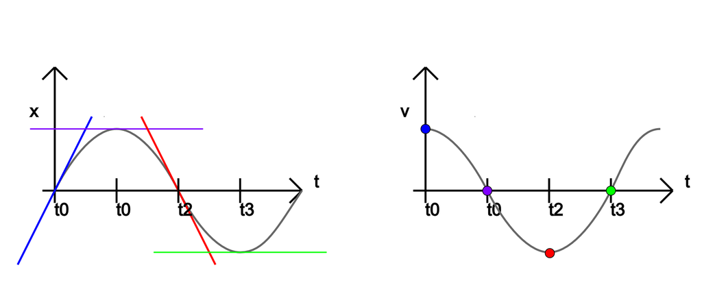

$$\vec{a} = \frac{d}{dt} \vec{v}$$

Once again, the derivative of velocity with respect to time represents the *slope* of the velocity vs. time plot at any particular time. Asking "what is my acceleration right now?" is the same as asking "at this very instant, how is my velocity changing?

These relationships between position, velocity, and acceleration might help you as you think about what the independent and dependent variables for your model of the block system might be. However, talking about these quantities has unfolded another wrinkle in the story.

You may have noticed that the variables $\vec{x},\vec{v}$ and $\vec{a}$ above were all written with arrows on top of them. This is because these are what we call *vector quantities,* meaning they have both a magnitude (how large are they?) and a direction (where are they pointed?). In the last reading, we said that a vector was a quantity that couldn't be described with just one number. That's still true! There are many ways to define and/or represent "vectors." Through the lens of physics, the idea of a vector in 2D or 3D space requiring a description involving a magnitude and direction fits our first definition nicely.

## Model Construction: Basics of 2-D Vectors in Cartesian Coordinates

In engineering, we represent any quantity that has both a size and a direction as a *vector*. Consider a boat traveling across the ocean from New York to London. If we represent East as the X direction, North as the Y direction, and look down on the boat from the sky, we might represent (or *model*) the boat's travel using the following picture.

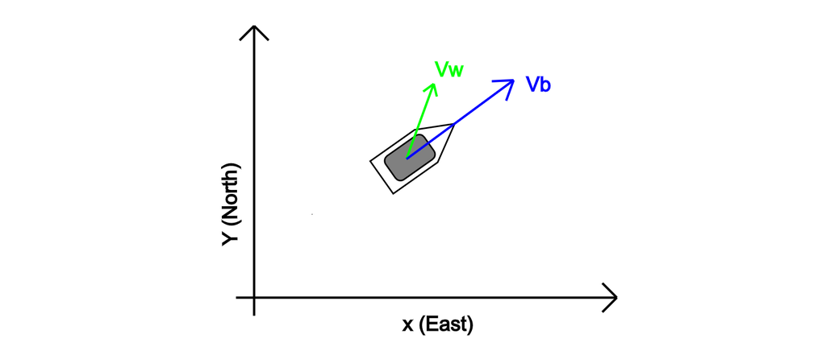

The boat's speed relative to the water due to its engine is given by the *scalar* quantity $v_b$, which does not specify its direction but only how fast the boat is going. We write $\vec{v}_b$ to indicate the boat's *velocity* as a vector quantity that has a particular direction. The boat is also moved relative to a fixed location on earth by currents in the water. The contribution of those currents to the boat's overall velocity can be written as $\vec{v}_w$. So what is the boat's total velocity? It is: $$\vec{v}_t = \vec{v}_b + \vec{v}_w$$

But if you can imagine this scenario in your head, you probably can intuit that **this is not the same** as writing the scalar equation: $$v_t = v_b + v_w$$

Because the water's velocity and the boat's velocity relative to that water are in *different directions*, so the boat's actual direction of motion will be somewhere in between the direction of $v_w$ and the direction of $v_b$. So how do we add vectors? By definition, vectors can be added using the *paralellogram law*, which is shown graphically below.

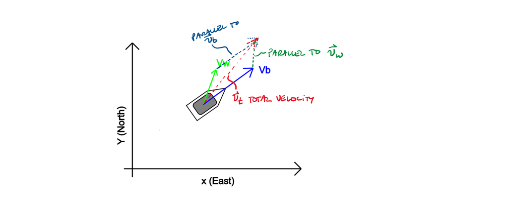

Thankfully, one of the fundamental consequences of paralellogram addition is that it allows us to break any vector up into *components,* or pieces, that are parallel to the axes we are interested in. In this case, that would be East (X) and North (Y). Let's try this for the velocity vector of the boat relative to the water, $\vec{v_b}$.

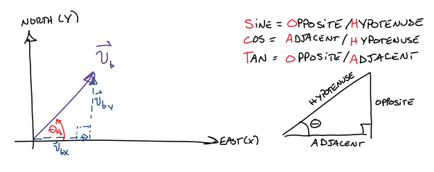

As the picture shows, we can imagine that the vector $\vec{v}_b$ is made up of two smaller vectors that are conveniently aligned with our X and Y axes. If we knew the magnitude $v_b$, we would then be able to see what the *magnitudes* of $\vec{v}_{bx}$ and $\vec{v}_{by}$ were by using the right triangle formed by aligning the component vectors "tip to tip" so that they end up at the arrow head of the total velocity of the boat relative to the water, $\vec{v}_b$. Using the mnemonic "SOH-CAH-TOA," reproduced to the right of our vector figure, we find that:

$$v_{bx} = v_b \cos \theta_{vb}$$$$v_{by} = v_b \sin \theta_{vb}$$

The pythagorean theorem combined with a quick trigonometric identity shows handily that the magnitude of $\vec{v}_b$, which we write as $v_b$, can be found as:

$$v_b = \sqrt{v_{bx}^2+v_{by}^2}$$

We can also write $\vec{v}_b$ in terms of these components when we consider that the "arrows" representing the size of the components can be expressed as vectors themselves:

$$\vec{v}_b = v_{bx}\hat{\imath} + v_{by} \hat{\jmath}$$

Where $\hat{\imath}$ is a "unit vector" of length 1 in the X-direction, which is scaled by $v_{bx}$, and $\hat{\jmath}$ is a "unit vector" of length 1 in the Y-direction, which is scaled by $v_{by}$. Generally speaking, the "hat" on top of a letter designates it as a unit vector (a vector with length 1).

Resolving *all* vectors of interest in our problem into components for a common set of axes in the fashion described above allows us to use scalar, rather than vector addition to find out what the *components* of $\vec{v}_t$ in the X and Y directions are. Once we have them, we could use them in a model to predict the boat's Northing and Easting position as functions of time. In this example, the total velocity for the boat, $\vec{v}_t$, can be written as follows:

$$ \vec{v}_t = v_{tx} \hat{\imath} + v_{ty} \hat{\jmath} $$

And each component can be found by summing the components of $\vec{v}_{b}$ and $\vec{v}_w$ in the X and Y directions:

$$v_{tx} = v_{bx} + v_{wx}$$$$v_{ty} = v_{by} + v_{wy}$$

Now that we have refreshed our memories about the relationships between position, velocity, and acceleration, along with how we can represent those quantities as vectors, you might imagine how you might express the motion of the block in the challenge. This may help you as you think about what the inputs and outputs of your system are, and perhaps how you might start to build relationships between these quantities as you construct your model.

But what factors *actually cause the block to move?* We need a *disciplined process* for building models of systems like this one... or else there is not much we can lean on when we move on to the **model construction** phase of the problem. For this course, the tools we will use for model construction in problems like this one are based on *Newton's Laws* of motion.

## Model Construction: Newton's Laws

One of the ways you are probably already familiar with building models for physical phenomena, perhaps from high school, is using Newton's Laws. We will actually use them extensively in this course as well! Newton's laws, applied to *rectilinear motion and linear momentum* are paraphrased below:

### Newton's First Law

If a frame of reference is *inertial*, an object will either remain at rest or move at constant velocity unless it is subjected to a nonzero net force. This can be written as "A net zero force implies no acceleration," which is represented by the equation:

$$ \Sigma \vec{F} = 0 \rightarrow \frac{d}{dt} \vec{v} = \vec{a} = 0$$

Notice that Force $\vec{F}$ is a vector quantity, meaning that it has both a magnitude and a direction, just like velocity and acceleration do.

### Newton's Second Law

The change in momentum of an object is directly proportional to the force applied. Changes in momentum occur in the *direction* of the net applied force. This can be written as the equation:

$$\Sigma \vec{F} = \frac{d}{dt} (m\vec{v})$$

If an object's mass is constant, the term $m$ can be pulled out of the derivative on the right-hand side, and the second law takes its more familiar form:

$$\Sigma \vec{F} = m\vec{a}$$

### Newton's Third Law

Forces between objects are equal in magnitude, but opposite in direction. This is one of the most helpful things to remember when constructing *free body diagrams* of objects that you wish to apply the second law to. If body A exerts a force $\vec{F}_{AB}$ on body B, then this is equal and opposite to the force $\vec{F}_{BA}$ that body B exerts on body A. Thus, we can write:

$$\vec{F}_{AB} = - \vec{F}_{BA}$$

Using these three laws, we should be able to get some idea of how an object's motion will evolve over time if it is subjected to forces, either from the "outside world" (inputs), or from other objects inside of our system boundary. But how can we actually *use* these equations? There is a tool called the Free Body Diagram (FBD) that is built specifically for this job.

## Model Construction: Free Body Diagrams (FBDs)

Using Newton's Laws for model construction often means determining the *motion* of an object when it is subjected to forces from the outside world, or in some cases, forces exerted on one element of a system by another. This can get complex very quickly, but the "Free Body Diagram" can help. A Free Body Diagram, or FBD, is a diagram in which one physical body is presented *on its own*, and all forces applied to the object are drawn on top of it as *vectors*.

Note that we are talking about the FBD in the context of the model construction step, but the FBD, which shows us how to *use or apply* Newton's Laws for a particular object, can also be very helpful in the System Scoping step of our overall modeling process. If the system you're describing can be modeled fairly as one distinct rigid object, it may be true that a single FBD could help show you what forces from "outside the system" are causing the motion of your object.

## Example: Model Construction Using an FBD and Newton's Laws

Consider the problem of modeling the following situation, in which a box is pulled along the ground by a string.

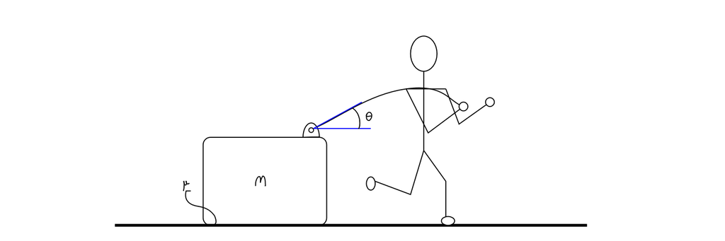

This problem setup could go many different ways. There are lots of possibilities for what we might know.

In this example, we will assume we know how hard the person is pulling on the box, and we know the angle at which they are pulling the string. We also know the friction coefficient between the mass and the ground, and the mass of the box (10kg). What we are after is a model of how the box moves. This allows us to Scope our system as follows:

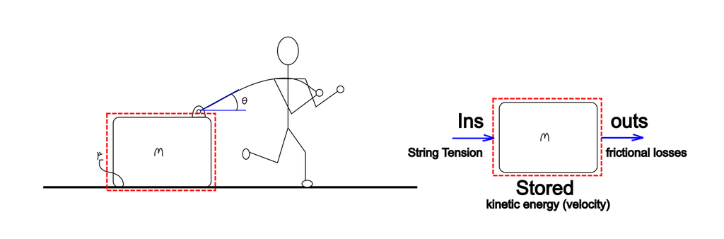

## Scoping

In this particular case, we can draw the system boundary around the box itself. There are other possibilities, but doing this means that the string can put energy IN to the system boundary by applying a force. If the box was moving, and the string is cut, it will stop because energy LEAVES the system boundary via friction between the ground and the box. The box itself, having some mass, stores kinetic energy (it moves).

## Construction

We know that our model should relate external inputs of string force and string angle (independent variables) to the box's position (dependent variable) over time. The model's independent variables will also include properties of the system of interest, such as mass and friction and the initial position and velocity of the box. It will use an equation based on Newton's Laws to yield the *output*, which in this problem is a prediction of the box's position as time marches on.

An FBD is, in this case, a complete representation of our system scope. This is not always true-- sometimes our system scope includes many interacting objects, each of which must be analyzed using Newton's Laws. But here, it is interesting to note that the box itself is the only "element" within the system boundary. So how do we draw an FBD for this system?

The picture above that shows the person pulling on the box is **not an FBD**, because it does not represent only one *body* in the application of Newton's Laws.

To construct an FBD, we need to draw the box by itself, and show all of the relevant forces that act on it so that we can resolve them into components, add them up, and apply Newton's Second Law to get equations that describe how the box will move as a function of time.

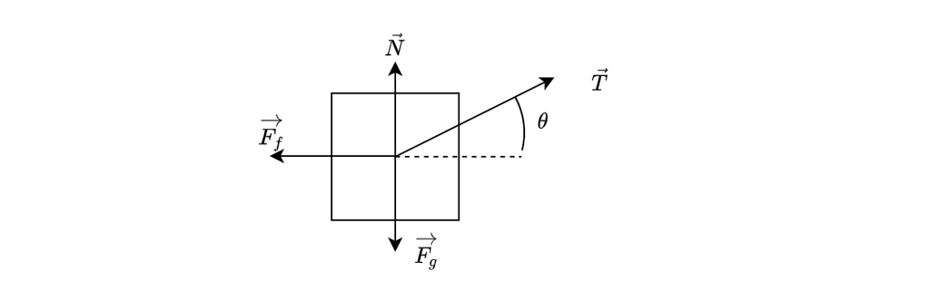

Great! The diagram is finished. But what is the process for connecting this strange picture with Newton's Laws?

## Model Construction: Constructing a model for translational motion using an FBD

Newton's Second Law tells us that the net applied force on an object is what causes it to accelerate. Acceleration causes velocity to change, and velocity causes position to change. The FBD is what tells us *what the net force on an object actually is*, and to calculate it, we use the diagram to *add up the vectors representing all forces applied to the object*. This allows for a specific sum of forces to fill in the left-hand side of the Newton's second law equation:

$$\Sigma \vec{F} = m \vec{a}$$

## Example: Connecting an FBD with Newton's Second Law

Considering our pulled-block example, I can resolve all of the forces on an FBD into components in the X and Y directions, and then write two scalar equations that represent the vector form of Newton's Second Law, $\Sigma \vec{F} = m\vec{a}$, because breaking a vector into components, as we saw before, allows us to replace vector addition with scalar addition.

$$\Sigma F_x = F_{fx} + T_x + F_{gx} + N_x = m a_x$$$$\Sigma F_y = F_{fy} + T_y + F_{gy} + N_y = m a_y$$

If all of these forces are known, then I can solve for the acceleration vector $\vec{a} = a_x \hat{\imath} + a_y \hat{\jmath}$, which will help tell me about how the box will move as time progresses. **After all of the forces have been summed in Newton's Second Law, it is important to take a step back and remind yourself what you are looking for.**. In this situation, the *output* of our model is $x$, which we know to be related to $a_x$. So we are "on the hunt" for an equation that relates $a_x$ to known properties of the model and/or inputs.

The particulars of each problem will dictate how Newton's Second Law is used, and will help us determine the values for each force in the second law equations. Here, given that the "coefficient of friction" is provided to us, we will try using a simple "dry friction" model to represent the interaction between the ground and the box to produce $\vec{F}_f$.

$$F_f = \mu N$$

Note that this is not a vector equation. The *direction* of $\vec{F}_f$ is always in opposition to motion. The *direction* of $\vec{N}$ is always *perpendicular to the supporting surface.* In this case, if I assume that the box does not lift off of the ground, I can use Newton's second law to say that the acceleration of the box is 0, which leads to the equation:

$$\Sigma F_y = F_{fy} + T_y + F_{gy} + N_y = 0$$

Looking at the equation, I see that $F_{fy}=0$ for this situation as drawn, and that $F_{gy} = -mg$. Note that $F_g$ points in the negative Y direction. This means that if it were to be resolved into components, and written $\vec{F}_g = F_{gx}\hat{\imath} + F_{gy}\hat{\jmath}$, I would find that $F_{gx}=0$ because the gravitational force points straight downwards. I would also find that $F_{gy}=-mg$, since the unit vector $\hat{\jmath}$ points in the positive Y direction by definition, meaning that it has to be "scaled" by a negative magnitude in order to point in the opposite direction.

Using this simplification, I could re-write Newton's Second Law for the Y direction as: $$T_y - mg + N_y = 0$$

Rearranging yields:

$$ N_y = mg-T_y = mg - T\sin \theta$$

Knowing $N_y$ means that we know $N$, since $N_x = 0$ in this problem. This now allows me to write an equation for the magnitude of $F_{fx}$, given that $F_{fy}=0$, which implies that $F_f = F_{fx} = \mu N$.

$$F_f = \mu N = \mu (mg-T\sin\theta)$$

The FBD shows us that this force will point in the negative x-direction, so it will need to be subtracted in our Newton's Second Law Equation. All of the quantities on the right-hand side of the equation are either inputs ($T$) or known properties of the model ($\mu,m,g,\theta$). This is good. Substituting this "new" knowledge back into the Newton's Second Law equation for the X direction, which contains $a_x$, or the quantity we were on the hunt for, yields: $$-\mu (mg-T\sin\theta) + T_x = m a_x$$

The only "unknown" quantity in the equation is now $T_x$, which we can calculate by resolving the X-component of the known force $\vec{T}$. This gives us $T_x = T\cos\theta$, which means that our Newton's Law equation for the X axis is now:

$$-\mu (mg-T\sin\theta) + T\cos\theta = m a_x$$

This equation now consists of all "known" quantities except one, $a_x$. So is the model done? **No!** We decided, in this example, that we were interested in the box's *position* as a function of time, not its acceleration! So how exactly could we go from acceleration, which we know is the time derivative of velocity, which we know is the time derivative of position, to position itself? Luckily, for this reading assignment's challenge, and for the pulled-block example, all forces are *constant*, which means that our acceleration is constant too.

Because the forces are all constant, using some simple equations will allow us to relate the block's acceleration to its position.

## Calculating position and velocity under constant acceleration

Because of the relationships between position, velocity, and acceleration:

$$\vec{a} = \frac{d}{dt} \vec{v}$$$$\vec{v} = \frac{d}{dt} \vec{x}$$

We can derive a special set of equations that can be used to calculate an object's position and velocity **in situations where acceleration is constant in both magnitude and direction**. These equations are based on the *rules of integration*. We will be more formal and deliberate with the concept of integration in a future discussion, but for now, think of an integral as an anti-derivative. In other words, if

$$\vec{a} = \frac{d}{dt} \vec{v}$$

Then, with the definition of the integral (which we denote by the symbol $\int$), we can say that: $$\vec{v} = \int \vec{a} dt$$ Likewise, if: $$\vec{v} = \frac{d}{dt} \vec{x}$$ Then, by the same definition, $$\vec{x} = \int \vec{v} dt$$

Where the subscript "0" indicates the position or velocity of the object at time $t=0$. Using the same relationship and notation for the corresponding y-component of acceleration, we could write:

$$v_y (t) = v_{y0} + a_y t$$$$y(t) = y_0 + v_{y0} t + \frac{1}{2} a_y t^2$$

This is the last "piece of the puzzle," if you will. You are now equipped with all of the tools you will need for this reading assignment's challenge, which represents another pass through the three fundamental steps we will use again and again in this course:

1. Model Scoping
2. Model Construction
3. Model Evaluation

# Assignment

With the review (or presentation) of the tools you'll need to tackle this reading's challenge, it's time to get specific. Once again, your job is to scope, construct, and evaluate a model for a block of wood sliding down an incline. A video of the experiment you'll use to evaluate your model is given below. In the video, the incline is $22.5^\circ$ above the horizontal, and the coefficient of friction between the block of wood and the aluminum material comprising the incline is known to be approximately $\mu=0.325$. When performing your model evaluation, it may be helpful to start and stop the video below, taking note of both the time (top left corner of the video) and the position of the edge of the block.

[video not shown]

## Deliverables

### System Scoping

Use www.draw.io or a cellphone screen shot showing your system scope, including pictorial representation(s) of element(s) in your model, and annotations indicating relevant quantities "in, out and stored" in your system scope.

### Model Construction

Use www.draw.io or a cellphone screen shot of your hand calculations to show the development of your model in the cell below. Be sure to explicitly call out independent and dependent variables in your model, including an indication of what your model's *output* will be.

### Model Evaluation

Use the code cell below to run and validate your model. Show a plot of your *predicted* block position *along the ramp* on top of a plot of *actual* block position. You will need to watch the video, pausing periodically to record the time and position of the block. These can be recorded as vectors in the code cell below for plotting. About 15-20 points of data should be enough.

```matlab
% YOUR CODE HERE
error('No Answer Given!')
```

[output not shown]